# Weather and CitiBike Data Findings

Patrick Lucey

Homepage

## Data Exploration Key Findings

The initial data exploration revealed several critical insights about the Citibike and weather dataset:

**Data Preparation** - Weather and Citibike datasets required merging and cleaning - Data quality issues necessitated significant tidying before analysis

**Temperature and Usage Patterns** - Non-linear relationship discovered between temperature and trip duration - Implemented spline regression to better model temperature effects - Summer months showed higher usage rates compared to other seasons

**Temporal Patterns** - Peak usage occurred during morning and evening rush hours - Trip duration remained consistent regardless of time of day - Weekday usage exceeded weekend usage

**Key Variables Identified** - Primary factors for analysis: * Temperature * Time of day * Day of week * User type

This summary can be included in your R Markdown document as an overview of your exploratory data analysis phase.

### SQL Queries used for analysis

```sql
WITH time_periods AS (
    SELECT
        cpw_temperature,
        usertype,
        CASE
            WHEN EXTRACT(HOUR FROM starttime) BETWEEN 6 AND 9 THEN 'Morning_Rush'
            WHEN EXTRACT(HOUR FROM starttime) BETWEEN 10 AND 15 THEN 'Midday'
            WHEN EXTRACT(HOUR FROM starttime) BETWEEN 16 AND 19 THEN 'Evening_Rush'
            ELSE 'Night'
        END AS time_bucket,
        CASE
            WHEN EXTRACT(DOW FROM starttime) IN (0, 6) THEN 'Weekend'
            ELSE 'Weekday'
        END AS day_type,
        starttime
    FROM citi_weather
    WHERE EXTRACT(YEAR FROM starttime) = 2019
        AND tripduration_min > 5 AND tripduration_min < 200  -- Trip duration range
)
SELECT
    usertype,
    time_bucket,
    day_type,
    EXTRACT(MONTH FROM starttime) as month,
    COUNT(*) as number_of_trips,
    AVG(cpw_temperature) as avg_temperature
FROM time_periods
GROUP BY
    usertype,
    time_bucket,
    day_type,
    EXTRACT(MONTH FROM starttime)
ORDER BY
    month,
    time_bucket;
```

## SQL Query Explanation

- **Purpose**: Analyze the relationship between temperature, time, and trip frequency
- **Time Buckets**:
  - Morning rush
  - Midday
  - Evening rush
  - Night
- **Variables Included**:
  - Average temperature
  - Number of trips
  - Time of day
  - Day of the week
  - Month
  - User type
- **Grouping Criteria**:
  - User type
  - Time bucket
  - Day type (weekday/weekend)
  - Month
- **Ordering**:
  - By month
  - Then by time bucket
- **Key Objectives**:
  - Identify patterns in trip frequency across different times of day
  - Examine variations in usage between weekdays and weekends
  - Analyze seasonal trends in bike-sharing usage
  - Investigate the impact of temperature on trip frequency
- **Expected Insights**:
  - Differences in usage patterns based on time of day
  - Variations in trip frequency between different user types
  - Seasonal trends in bike-sharing demand
  - Correlation between temperature and number of trips

### Exploratory Data Visuals

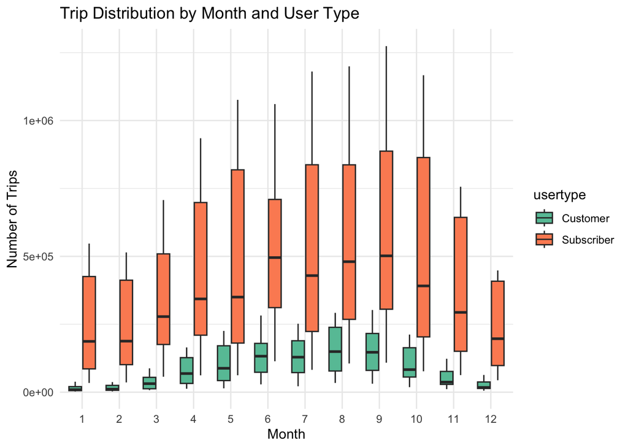

```r
ggplot(avg_temp_data, aes(x = factor(month), y = number_of_trips)) +
  geom_boxplot(aes(fill = usertype)) +
  labs(x = "Month", y = "Number of Trips",
       title = "Trip Distribution by Month and User Type") +
  theme_minimal() +
  scale_fill_brewer(palette = "Set2")
```

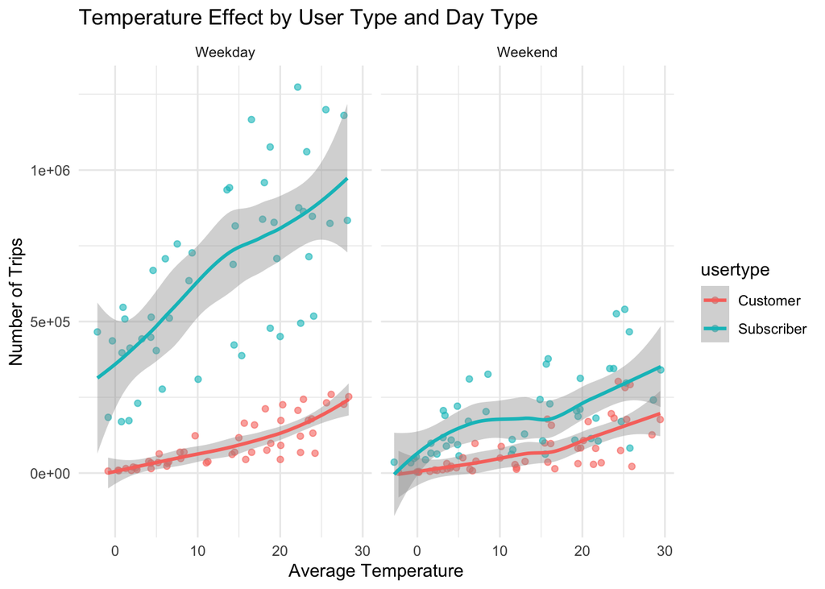

```r
# Temperature Effect by User Type
ggplot(avg_temp_data, aes(x = avg_temperature, y = number_of_trips)) +
  geom_point(aes(color = usertype), alpha = 0.6) +
  geom_smooth(aes(color = usertype), method = "loess") +
  facet_wrap(~day_type) +
  labs(x = "Average Temperature", y = "Number of Trips",
       title = "Temperature Effect by User Type and Day Type") +
  theme_minimal()
## `geom_smooth()` using formula = 'y ~ x'
```

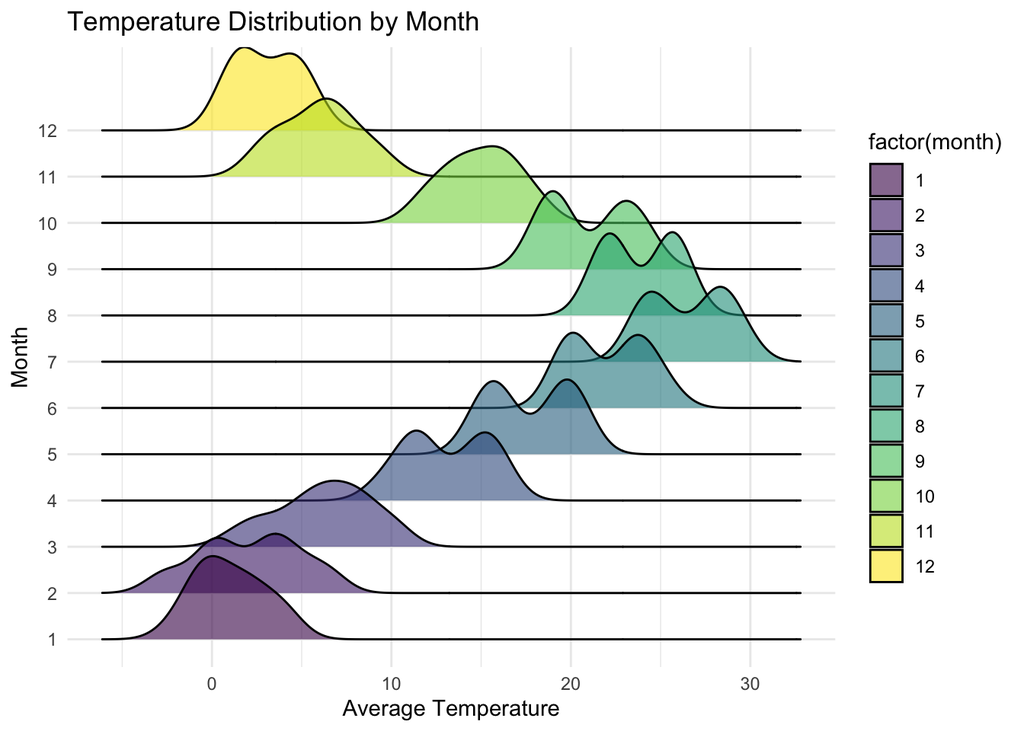

```r
# Ridge plot of temperature distribution by month
library(ggridges)
ggplot(avg_temp_data, aes(x = avg_temperature, y = factor(month))) +
  geom_density_ridges(aes(fill = factor(month)), alpha = 0.6) +
  scale_fill_viridis_d() +
  labs(x = "Average Temperature", y = "Month",
       title = "Temperature Distribution by Month") +
  theme_minimal()
## Picking joint bandwidth of 1.1
```

## Key Findings from Plot Analysis

**User Type Patterns** - Subscribers consistently take more trips than customers throughout the year - Customer trip patterns remain similar between weekdays and weekends - Subscriber trips show significant increase during weekdays, especially at higher temperatures

**Seasonal Trends** - Higher trip frequency during summer months - Temperature shows positive correlation with number of trips - Temperature distribution peaks during summer months, as shown in ridge plot

**Temperature Effects** - Positive relationship between temperature and trip frequency - Impact varies by user type: * Subscribers: Strong positive correlation on weekdays * Customers: Consistent pattern regardless of day type

**Weekday vs Weekend Analysis** - Higher trip frequency on weekdays overall - User type differences: * Subscribers: Notable weekday preference * Customers: Similar patterns across all days

**Model Implications** - Temperature-trip relationship warrants further investigation through Poisson regression - Seasonal patterns strongly influence usage behavior - User type and day type are significant factors in trip frequency

These findings support the initial exploratory data analysis and provide foundation for more detailed statistical modeling. The visualizations help identify key trends and relationships in the data, guiding the subsequent analysis and Poisson Regression development. # Model - Number of Trips

## Correlation Matrix of Variables used in the Poisson Regression Model

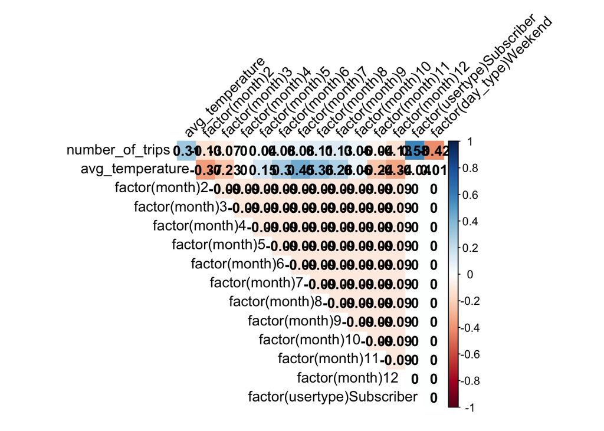

```r
# Create correlation matrix
# Extract numeric variables and create dummy variables for factors
model_matrix <- model.matrix(~ number_of_trips
                             + avg_temperature
                             + factor(month)
                             + factor(usertype)
                             + factor(day_type),
                             data = avg_temp_data)[,-1]

# Calculate correlation matrix
cor_matrix <- cor(model_matrix)

# Create correlation plot
corrplot(cor_matrix,
         method = "color",
         type = "upper",
         addCoef.col = "black",
         tl.col = "black",
         tl.srt = 45,
         diag = FALSE)
```